# Lecture 3: Scatter plots and regression

Jack Blundell

PUBLPOL 330D Applied Econometrics for Public Policy, Winter 2020

- My email: jackblundell@stanford.edu
- My office hours: 8.30 - 10.30am every Thursday at Econ 350 (Landau building)
- Section (further office hours): 2.30 - 3.20pm (Bass B312)

# 1. Scatter plots

So far we have seen *histograms* and *box plots*. A third useful plot to draw is a *scatter plot*.

Scatter plots are very common when you would like to see the relationship between two continuous variables.

First I set up my workspace and simulate some data:

```stata
. // set directory
. cd "~/Dropbox/Documents/Teaching/PUBLPOL330D/Lectures/Lecture 3/markdown"
/Users/jack/Dropbox/Documents/Teaching/PUBLPOL330D/Lectures/Lecture 3/markdown
```

```stata
. // set seed
. set seed 123
```

```stata
. // simulate data
. clear

. set obs 1000
number of observations (_N) was 0, now 1,000

. gen x = rnormal(0,0.1)

. gen z = 0.3*(x) + rnormal(0,0.1)

. gen y = x + 0.5*(z) + rnormal(0,0.1)
```

I have three variables, and would like to plot the relationship between `y` and `x`.

The command for this is `twoway scatter` followed by the y-axis variable then the x-axis variable. Here is an example:

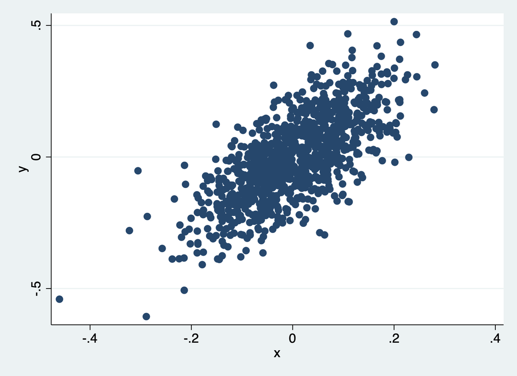

Scatter plot

```stata
. // scatter plot
. twoway scatter y x

. graph export "scatterplot.png", replace
(file scatterplot.png written in PNG format)
```

# 2. Simple regression in Stata

The Stata command for regression is `regress` or `reg` for short. Here is a regression of `y` on `x` in our simulated data:

```stata
. regress y x

      Source │       SS           df       MS      Number of obs   =     1,000
─────────────┼──────────────────────────────────   F(1, 998)       =    991.97
       Model │  12.8742974         1  12.8742974   Prob > F        =    0.0000
    Residual │  12.9525759       998  .012978533   R-squared       =    0.4985
─────────────┼──────────────────────────────────   Adj R-squared   =    0.4980
       Total │  25.8268733       999  .025852726   Root MSE        =    .11392

─────────────┬────────────────────────────────────────────────────────────────
           y │      Coef.   Std. Err.      t    P>|t|     [95% Conf. Interval]
─────────────┼────────────────────────────────────────────────────────────────
           x │   1.167971   .0370837    31.50   0.000       1.0952    1.240742
       _cons │   -.003084   .0036034    -0.86   0.392     -.010155    .0039871
─────────────┴────────────────────────────────────────────────────────────────
```

The slope estimate is 1.170, with a standard error of 0.037. The slope is statistically significant, with a p value of <0.01.

We can add the fitted line on the graph as follows:

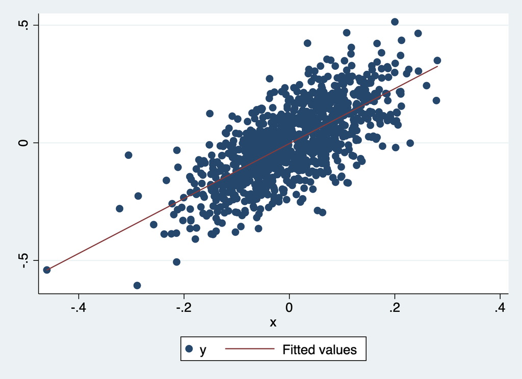

Scatter plot

```stata
. twoway (scatter y x) (lfit y x)

. graph export "scatterplot_lfit.png", replace
(file scatterplot_lfit.png written in PNG format)
```

# 3. Multivariate regression in Stata

If we want to include more variables on the right hand side of a regression, we just add them to the end of the regression command. Here I estimate a regression of `y` on `x` and `z` together:

```stata
. // run regression
. reg y x z

      Source │       SS           df       MS      Number of obs   =     1,000
─────────────┼──────────────────────────────────   F(2, 997)       =    746.98
       Model │  15.4897448         2  7.74487239   Prob > F        =    0.0000
    Residual │  10.3371285       997  .010368233   R-squared       =    0.5998
─────────────┼──────────────────────────────────   Adj R-squared   =    0.5990
       Total │  25.8268733       999  .025852726   Root MSE        =    .10182

─────────────┬────────────────────────────────────────────────────────────────
           y │      Coef.   Std. Err.      t    P>|t|     [95% Conf. Interval]
─────────────┼────────────────────────────────────────────────────────────────
           x │   1.015388   .0345095    29.42   0.000     .9476689    1.083108
           z │   .5136313   .0323393    15.88   0.000     .4501704    .5770922
       _cons │  -.0041282   .0032214    -1.28   0.200    -.0104496    .0021933
─────────────┴────────────────────────────────────────────────────────────────
```

Both `x` and `z` are highly statistically significant.

As with previous commands, options can be added and the sample can be limited. Here I subset to those with a negative value for `z` and use robust standard errors:

```stata
. reg y x z if z < 0, robust

Linear regression                               Number of obs     =        503
                                                F(2, 500)         =     307.99
                                                Prob > F          =     0.0000
                                                R-squared         =     0.5380
                                                Root MSE          =     .09835

─────────────┬────────────────────────────────────────────────────────────────
             │               Robust
           y │      Coef.   Std. Err.      t    P>|t|     [95% Conf. Interval]
─────────────┼────────────────────────────────────────────────────────────────
           x │   .9966302   .0451005    22.10   0.000     .9080204     1.08524
           z │   .4647155   .0616661     7.54   0.000     .3435589    .5858721
       _cons │  -.0087436   .0066394    -1.32   0.188    -.0217882    .0043011
─────────────┴────────────────────────────────────────────────────────────────
```